# Question

In an [approval-vote election](https://en.wikipedia.org/wiki/Approval_voting), there are 4 candidates and 185 voters. Each voter indicated which candidates they approve of (with a “Y”) or disapprove of (with a “N”). All possible ballots are shown below, and the table indicates how many of each type of ballot was cast.

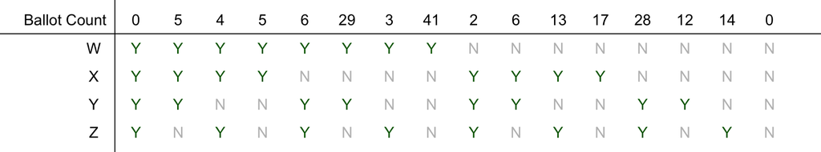

(You probably want to copy/paste this table into [sheets](https://sheets.new).)

1. How many approvals did Candidate W get? ##ANSWER1##
2. How many approvals did Candidate X get? ##ANSWER2##
3. How many approvals did Candidate Y get? ##ANSWER3##
4. How many approvals did Candidate Z get? ##ANSWER4##
5. Who won the election? ##ANSWER5##

## Answerlist

- 49
- 50
- 52
- 54
- 68
- 70
- 88
- 90
- 93
- 95
- 49
- 50
- 52
- 54
- 68
- 70
- 88
- 90
- 93
- 95
- 49
- 50
- 52
- 54
- 68
- 70
- 88
- 90
- 93
- 95
- 49
- 50
- 52
- 54
- 68
- 70
- 88
- 90
- 93
- 95
- Candidate W
- Candidate X
- Candidate Y
- Candidate Z

# Solution

Each “Y” corresponds to the ballot count number of votes. We can make another table with votes counts.

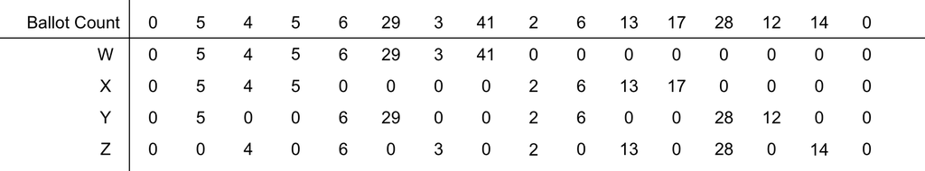

And then just sum each row.

- Candidate W got 93 approvals
- Candidate X got 52 approvals
- Candidate Y got 88 approvals
- Candidate Z got 70 approvals

And we see that Candidate W is the winner.

# Meta-information

extype: cloze exclozetype: schoice|schoice|schoice|schoice|schoice exsolution: 0000000010|0010000000|0000001000|0000010000|1000 exname: approval